# Lab 2: Cumulative deaths from COVID-19

## Introduction

In this lab we work with visualization, data wrangling, and dates. Yeah! Analytics 2 is *SO MUCH FUN!*

As you know, countries around the world are responding to an outbreak of respiratory illness caused by a novel coronavirus, COVID-19. The outbreak first started in Wuhan, China, but cases have been identified in a growing number of other locations internationally, including the United States. In this report we explore how the trajectory of the cumulative deaths in a number of countries.

The data come from the **coronavirus** package, which pulls data from the Johns Hopkins University Center for Systems Science and Engineering (JHU CCSE) Coronavirus repository. The coronavirus package provides a tidy format dataset of the 2019 Novel Coronavirus COVID-19 (2019-nCoV) epidemic. The package is available on GitHub [here](https://github.com/RamiKrispin/coronavirus) and is updated daily.

> For your ease of use, I have placed data on brightspace that you may use for this assignent, but you can grab more current data from the source above, if you like.

For our analysis, in addition to the coronavirus package, I may* use the following packages for data wrangling and visualization. You are only required to use `tidyverse` for data wrangling and visualization and package `lubridate` for handling dates

- **tidyverse** for data wrangling and visualization
- **lubridate** package for handling dates
- **glue** package for constructing text strings
- **scales** package for formatting axis labels
- **ggrepel** package for pretty printing of country labels

I make use of the **DT** package for interactive display of tabular output in the Appendix, but you may use another way to display your results.

```r
library(coronavirus) # devtools::install_github("RamiKrispin/coronavirus")
library(tidyverse)
library(lubridate)
library(glue)
library(scales)
library(ggrepel)
library(DT)
```

## Data prep

The data frame called `coronavirus` in the coronavirus package provides a daily summary of the Coronavirus (COVID-19) cases by country. Each row in the data frame represents a country (or, where relevant, state/province). A full list of the countries in the data frame is provided in the Appendix. Note that the data provided in this package provides daily number of deaths, confirmed cases, and recovered cases. For this report, we will focus on the deaths.

We will start by making our selection for the countries we want to explore.

1. Select these countries to study: “China”, “France”, “United Kingdom”, “US”, and “Turkey”

We also need to take a note of the “as of date” for the data so that we can properly label our visualisation.

These data are as of Sat, Jan 9, 2021.

## Visualisation

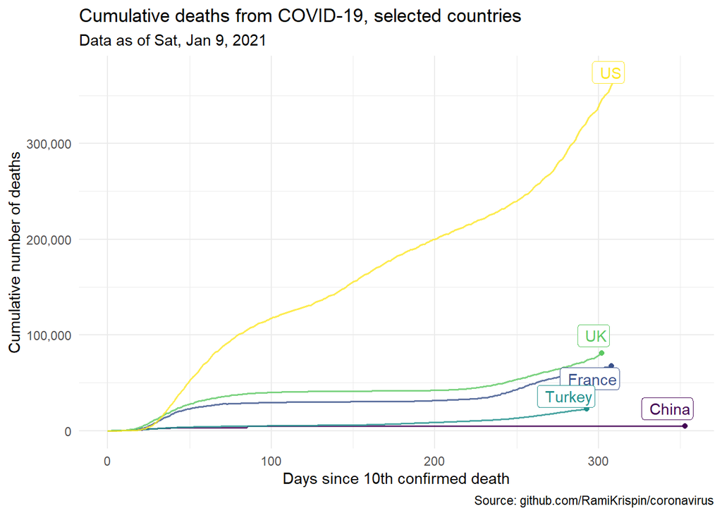

## Appendix

A list of countries in the `coronavirus` data frame is provided below.

|  | country |
| --- | --- |
| 1 | Afghanistan |
| 2 | Albania |
| 3 | Algeria |
| 4 | Andorra |
| 5 | Angola |
| 6 | Antigua and Barbuda |
| 7 | Argentina |
| 8 | Armenia |
| 9 | Australia |
| 10 | Austria |

[output cut: 181 more lines]